# Ensemble Simulations

Monte Carlo probabilistic fire forecasting

Ensemble simulations run multiple realizations of a fire scenario with perturbed inputs to generate probabilistic forecasts. This tutorial covers Elmfire.jl’s ensemble capabilities.

```julia
using Elmfire
using Plots
using Random
Random.seed!(42)
```

```
TaskLocalRNG()
```

## Why Ensembles?

Fire behavior is inherently uncertain due to:

- **Weather variability** - Wind speed and direction fluctuate
- **Fuel moisture uncertainty** - Difficult to measure accurately everywhere
- **Ignition location uncertainty** - GPS errors, multiple potential sources
- **Model limitations** - Simplified physics can’t capture all dynamics

Ensembles quantify this uncertainty by running many simulations with slightly different inputs.

## Basic Ensemble Configuration

Set up perturbation parameters:

```julia
# Define perturbation ranges
perturbation = PerturbationConfig{Float64}(
    ignition_perturb_radius = 3.0,           # ±3 cells around ignition
    wind_speed_factor_range = (0.8, 1.2),    # ±20% wind speed
    wind_direction_std = 15.0,               # 15° standard deviation
    moisture_factor_range = (0.85, 1.15),    # ±15% moisture
    spread_rate_factor_range = (0.9, 1.1)    # ±10% spread rate
)

# Configure the ensemble
config = EnsembleConfig{Float64}(
    n_simulations = 50,                      # Number of ensemble members
    base_seed = UInt64(12345),               # For reproducibility
    perturbation = perturbation,
    simulation_config = SimulationConfig{Float64}(),
    save_individual_results = true           # Keep individual member results
)
```

```
EnsembleConfig{Float64}(50, 0x0000000000003039, PerturbationConfig{Float64}(3.0, (0.8, 1.2), 15.0, (0.85, 1.15), (0.9, 1.1)), SimulationConfig{Float64}(false, false, 1.0, 0.39, 100.0, 250.0, 1.0, nothing, false), true)
```

## Running an Ensemble

```julia
# Set up the simulation domain
ncols, nrows = 80, 80
cellsize = 30.0

state_template = FireState{Float64}(ncols, nrows, cellsize)
fuel_table = create_standard_fuel_table(Float64)
fuel_ids = fill(1, ncols, nrows)  # Uniform short grass
slope = zeros(Float64, ncols, nrows)
aspect = zeros(Float64, ncols, nrows)

# Base weather conditions
weather = ConstantWeather{Float64}(
    wind_speed_mph = 12.0,
    wind_direction = 270.0,
    M1 = 0.06, M10 = 0.08, M100 = 0.10,
    MLH = 0.60, MLW = 0.90
)

# Run the ensemble
result = run_ensemble!(
    config,
    state_template,
    fuel_ids,
    fuel_table,
    weather,
    slope,
    aspect,
    40, 40,     # Ignition point (center)
    0.0, 45.0;  # 45 minutes
    show_progress = false
)

println("Ensemble completed: $(length(result.members)) members")
println("Mean burned area: $(round(result.mean_burned_area, digits=2)) ± $(round(result.std_burned_area, digits=2)) acres")
```

```
Ensemble completed: 50 members
Mean burned area: 16.02 ± 2.78 acres
```

## Burn Probability Map

The burn probability shows the likelihood each cell burns across all ensemble members:

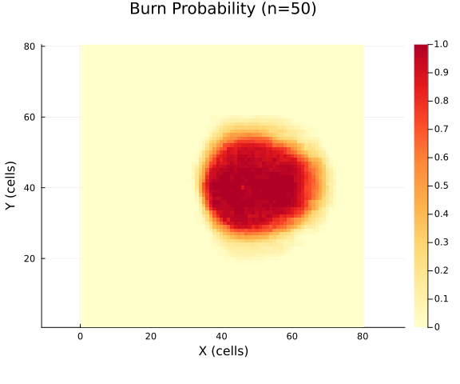

```julia
heatmap(
    result.burn_probability',
    title = "Burn Probability (n=$(config.n_simulations))",
    xlabel = "X (cells)",
    ylabel = "Y (cells)",
    color = :YlOrRd,
    clims = (0, 1),
    aspect_ratio = 1,
    size = (600, 500)
)
```

### Interpreting Burn Probability

- **1.0 (100%)**: Cell burned in all simulations - high confidence area
- **0.5 (50%)**: Cell burned in half of simulations - moderate uncertainty
- **0.0 (0%)**: Cell never burned - outside potential fire extent

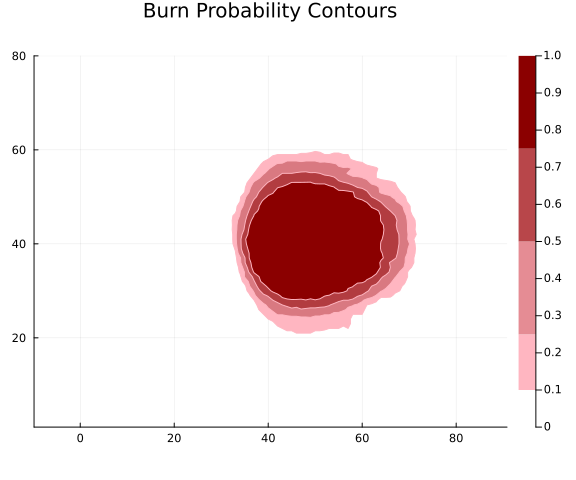

```julia
# Probability contours
contour(
    result.burn_probability',
    title = "Burn Probability Contours",
    levels = [0.1, 0.25, 0.5, 0.75, 0.9],
    color = :reds,
    fill = true,
    aspect_ratio = 1,
    size = (600, 500)
)
```

## Mean Arrival Time

Average time of arrival across ensemble members (for cells that burned):

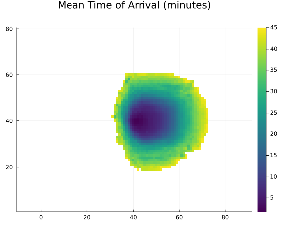

```julia
mean_toa = copy(result.mean_arrival_time)
mean_toa[mean_toa .< 0] .= NaN

heatmap(
    mean_toa',
    title = "Mean Time of Arrival (minutes)",
    color = :viridis,
    aspect_ratio = 1,
    size = (600, 500)
)
```

## Individual Ensemble Members

With `save_individual_results = true`, we can examine specific members:

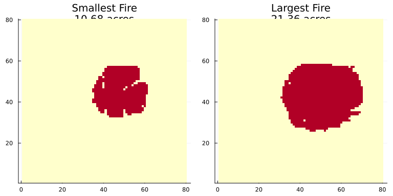

```julia
# Compare smallest and largest fires
areas = [m.burned_area_acres for m in result.members]
min_idx = argmin(areas)
max_idx = argmax(areas)

p1 = heatmap(result.members[min_idx].burned',
    title = "Smallest Fire\n$(round(areas[min_idx], digits=2)) acres",
    color = :YlOrRd, aspect_ratio = 1, colorbar = false)

p2 = heatmap(result.members[max_idx].burned',
    title = "Largest Fire\n$(round(areas[max_idx], digits=2)) acres",
    color = :YlOrRd, aspect_ratio = 1, colorbar = false)

plot(p1, p2, layout = (1, 2), size = (800, 400))
```

## Burned Area Distribution

Examine the distribution of burned area across ensemble members:

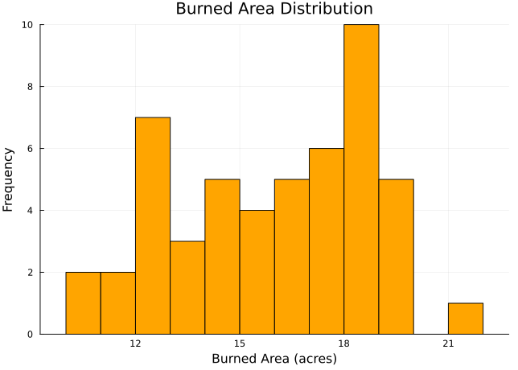

```julia
areas = [m.burned_area_acres for m in result.members]

histogram(areas,
    xlabel = "Burned Area (acres)",
    ylabel = "Frequency",
    title = "Burned Area Distribution",
    legend = false,
    bins = 15,
    color = :orange
)
```

```julia
# Statistics
println("Burned Area Statistics:")
println("  Minimum: $(round(minimum(areas), digits=2)) acres")
println("  25th percentile: $(round(sort(areas)[div(end,4)], digits=2)) acres")
println("  Median: $(round(sort(areas)[div(end,2)], digits=2)) acres")
println("  75th percentile: $(round(sort(areas)[3*div(end,4)], digits=2)) acres")
println("  Maximum: $(round(maximum(areas), digits=2)) acres")
```

```
Burned Area Statistics:
  Minimum: 10.68 acres
  25th percentile: 13.35 acres
  Median: 16.71 acres
  75th percentile: 18.16 acres
  Maximum: 21.36 acres
```

## Exceedance Probability

Calculate the probability that fire exceeds a given size:

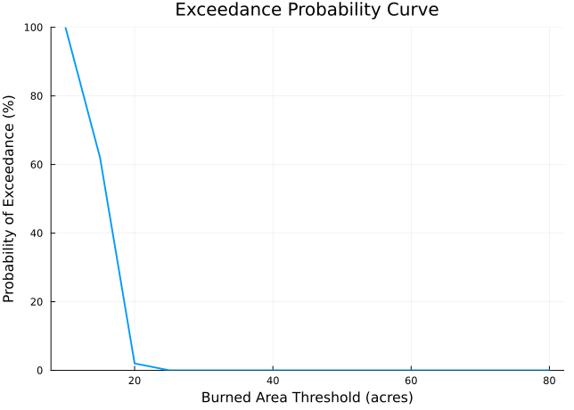

```julia
thresholds = 10:5:80
probs = [get_exceedance_probability(result, Float64(t)) for t in thresholds]

plot(thresholds, probs .* 100,
    xlabel = "Burned Area Threshold (acres)",
    ylabel = "Probability of Exceedance (%)",
    title = "Exceedance Probability Curve",
    linewidth = 2,
    legend = false,
    ylims = (0, 100)
)
```

## Percentile Fires

Get representative fires at specific percentiles:

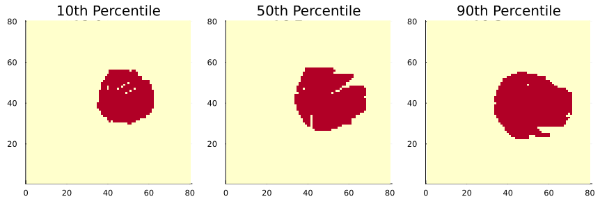

```julia
percentiles = [10, 50, 90]
plots = []

for p in percentiles
    member = get_percentile_fire(result, Float64(p))
    push!(plots, heatmap(member.burned',
        title = "$(p)th Percentile\n$(round(member.burned_area_acres, digits=1)) acres",
        color = :YlOrRd, aspect_ratio = 1, colorbar = false))
end

plot(plots..., layout = (1, 3), size = (900, 300))
```

## Convergence Analysis

Check if the ensemble has converged (burn probability stabilizing):

```julia
plot(result.convergence_history,
    xlabel = "Ensemble Member",
    ylabel = "RMS Change in Burn Probability",
    title = "Ensemble Convergence",
    linewidth = 1.5,
    legend = false,
    yscale = :log10
)

println("Converged: ", check_convergence(result, threshold = 0.001))
```

[output not shown]

```
Converged: false
```

## Effect of Ensemble Size

Compare ensembles of different sizes:

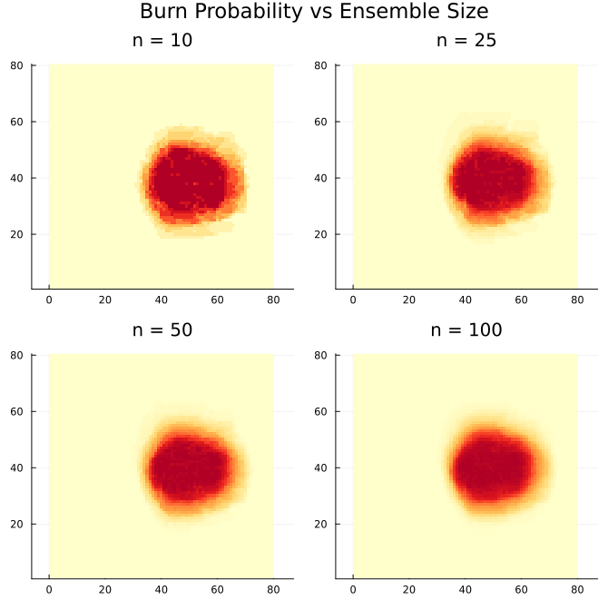

```julia
ensemble_sizes = [10, 25, 50, 100]
burn_prob_maps = []

for n in ensemble_sizes
    cfg = EnsembleConfig{Float64}(
        n_simulations = n,
        base_seed = UInt64(42),
        perturbation = perturbation,
        simulation_config = SimulationConfig{Float64}(),
        save_individual_results = false
    )

    res = run_ensemble!(cfg, state_template, fuel_ids, fuel_table, weather,
        slope, aspect, 40, 40, 0.0, 45.0; show_progress = false)

    push!(burn_prob_maps, heatmap(res.burn_probability',
        title = "n = $n",
        color = :YlOrRd, clims = (0, 1),
        aspect_ratio = 1, colorbar = false))
end

plot(burn_prob_maps..., layout = (2, 2), size = (700, 700),
    plot_title = "Burn Probability vs Ensemble Size")
```

## Parallel Ensemble Execution

For large ensembles, use multi-threading:

```julia
# Check available threads
println("Available threads: ", Threads.nthreads())

# Parallel configuration
parallel_config = ParallelConfig(n_workers = 0, chunk_size = 1)  # 0 = auto-detect

# Larger ensemble for parallel demo
large_config = EnsembleConfig{Float64}(
    n_simulations = 100,
    base_seed = UInt64(99),
    perturbation = perturbation,
    save_individual_results = false
)

# Run threaded ensemble
@time result_parallel = run_ensemble_threaded!(
    large_config,
    state_template,
    fuel_ids,
    fuel_table,
    weather,
    slope,
    aspect,
    40, 40,
    0.0, 45.0;
    parallel_config = parallel_config,
    show_progress = false
)

println("Threaded ensemble mean area: $(round(result_parallel.mean_burned_area, digits=2)) acres")
```

```
Available threads: 1
  9.593298 seconds (149.34 M allocations: 3.083 GiB, 2.85% gc time, 4.66% compilation time)
Threaded ensemble mean area: 15.81 acres
```

## Sensitivity to Perturbation Magnitude

Explore how uncertainty ranges affect results:

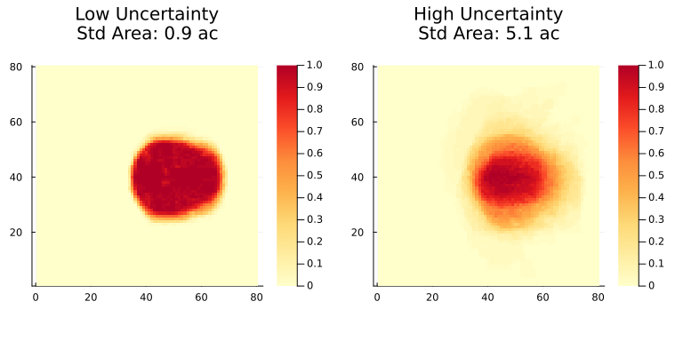

```julia
# Low uncertainty
low_pert = PerturbationConfig{Float64}(
    ignition_perturb_radius = 1.0,
    wind_speed_factor_range = (0.95, 1.05),
    wind_direction_std = 5.0,
    moisture_factor_range = (0.95, 1.05)
)

# High uncertainty
high_pert = PerturbationConfig{Float64}(
    ignition_perturb_radius = 5.0,
    wind_speed_factor_range = (0.6, 1.4),
    wind_direction_std = 30.0,
    moisture_factor_range = (0.7, 1.3)
)

plots = []
for (pert, label) in [(low_pert, "Low Uncertainty"), (high_pert, "High Uncertainty")]
    cfg = EnsembleConfig{Float64}(
        n_simulations = 50,
        base_seed = UInt64(42),
        perturbation = pert,
        save_individual_results = false
    )

    res = run_ensemble!(cfg, state_template, fuel_ids, fuel_table, weather,
        slope, aspect, 40, 40, 0.0, 45.0; show_progress = false)

    push!(plots, heatmap(res.burn_probability',
        title = "$label\nStd Area: $(round(res.std_burned_area, digits=1)) ac",
        color = :YlOrRd, clims = (0, 1), aspect_ratio = 1))
end

plot(plots..., layout = (1, 2), size = (800, 400))
```

## Practical Applications

### 1. Evacuation Planning

Use exceedance probabilities to identify areas at risk:

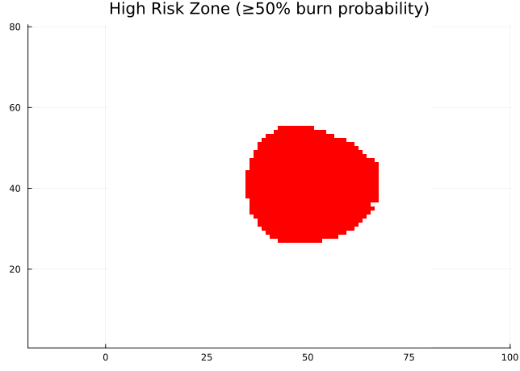

```julia
# Areas with >50% chance of burning within 45 minutes
high_risk = result.burn_probability .>= 0.5

heatmap(high_risk',
    title = "High Risk Zone (≥50% burn probability)",
    color = [:white, :red],
    aspect_ratio = 1,
    colorbar = false
)
```

### 2. Resource Pre-positioning

Identify areas where fire is likely to spread next:

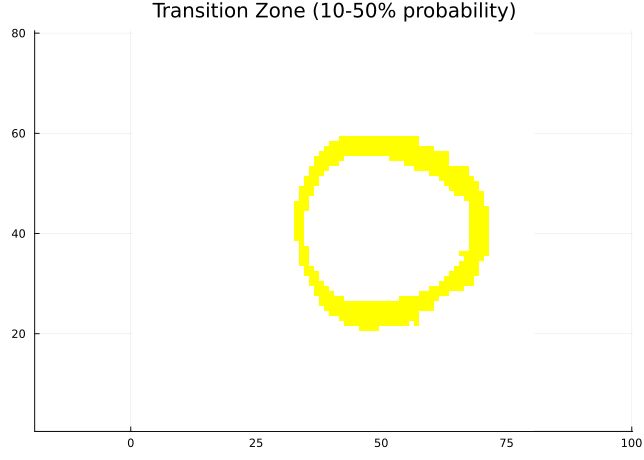

```julia
# Areas with 10-50% probability (transition zone)
transition_zone = (result.burn_probability .>= 0.1) .& (result.burn_probability .< 0.5)

heatmap(transition_zone',
    title = "Transition Zone (10-50% probability)",
    color = [:white, :yellow],
    aspect_ratio = 1,
    colorbar = false
)
```

### 3. Communicating Uncertainty

Present multiple scenarios to decision makers:

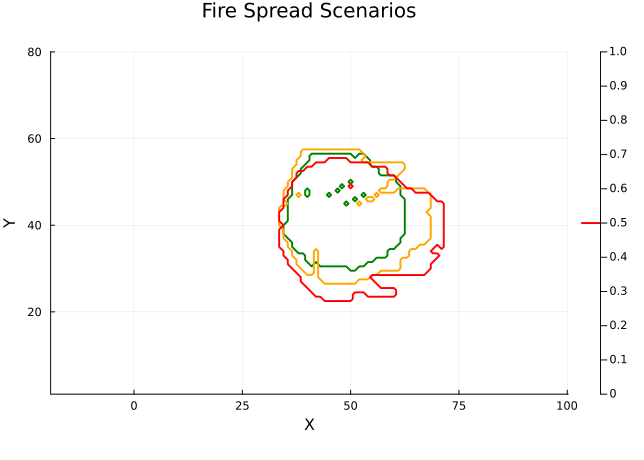

```julia
# Get 10th, 50th, and 90th percentile scenarios
small = get_percentile_fire(result, 10.0)
median = get_percentile_fire(result, 50.0)
large = get_percentile_fire(result, 90.0)

# Overlay contours
p = plot(aspect_ratio = 1, legend = :topleft,
    title = "Fire Spread Scenarios",
    xlabel = "X", ylabel = "Y")

# Find perimeters (simplified as contours of burned area)
contour!(p, Float64.(small.burned)', levels = [0.5],
    linecolor = :green, linewidth = 2, label = "10th percentile")
contour!(p, Float64.(median.burned)', levels = [0.5],
    linecolor = :orange, linewidth = 2, label = "50th percentile")
contour!(p, Float64.(large.burned)', levels = [0.5],
    linecolor = :red, linewidth = 2, label = "90th percentile")

p
```

## Best Practices

1. **Ensemble Size**: Start with 50-100 members; increase if convergence is poor
2. **Perturbation Ranges**: Base on actual measurement/forecast uncertainty
3. **Seed Setting**: Use consistent seeds for reproducibility
4. **Save Results**: Store ensemble output for post-processing
5. **Parallel Execution**: Use threading for ensembles > 50 members